# Zoo classification

Satsawat N.

January 03, 2017

## Zoo Animal Classification

The aim is to use Machine Learning Methods to Correctly Classify Animals Based Upon Attributes.

### Overview

This data is available from [Kaggle](https://www.kaggle.com/uciml/zoo-animal-classification), which is published by [UCI ML](https://www.kaggle.com/uciml).

There are 2 datasets, namely:

1. Class dataset - this provides the class name to the class type as well as the list of animals which are corresponding to the class.

```
##   Class_Number Number_Of_Animal_Species_In_Class Class_Type
## 1            1                                41     Mammal
## 2            2                                20       Bird
##                                                                                                                                                                                                                                                                                                          …
## 1 aardvark, antelope, bear, boar, buffalo, calf, cavy, cheetah, deer, dolphin, elephant, fruitbat, giraffe, girl, goat, gorilla, hamster, hare, leopard, lion, lynx, mink, mole, mongoose, opossum, oryx, platypus, polecat, pony, porpoise, puma, pussycat, raccoon, reindeer, seal, sealion, squirrel, …
## 2                                                                                                                                                                                chicken, crow, dove, duck, flamingo, gull, hawk, kiwi, lark, ostrich, parakeet, penguin, pheasant, rhea, skimmer, skua, …
```

2. Zoo - this data consists of the animal names with their features and the class which they are belong. This is what we trying to predict.

```
##   animal_name hair feathers eggs milk airborne aquatic predator toothed
## 1    aardvark    1        0    0    1        0       0        1       1
## 2    antelope    1        0    0    1        0       0        0       1
##   backbone breathes venomous fins legs tail domestic catsize class_type
## 1        1        1        0    0    4    0        0       1          1
## 2        1        1        0    0    4    1        0       1          1
```

Note that we can use these 2 datasets to join each other to get full information.

```r
zoo.data <- merge(x = raw.data, y = class.data, by = "class_type", all.x = TRUE)
```

```
##   class_type animal_name hair feathers eggs milk airborne aquatic predator
## 1          1    aardvark    1        0    0    1        0       0        1
## 2          1    antelope    1        0    0    1        0       0        0
## 3          1     giraffe    1        0    0    1        0       0        0
##   toothed backbone breathes venomous fins legs tail domestic catsize
## 1       1        1        1        0    0    4    0        0       1
## 2       1        1        1        0    0    4    1        0       1
## 3       1        1        1        0    0    4    1        0       1
##   class_name
## 1     Mammal
## 2     Mammal
## 3     Mammal
```

### Visualize the data

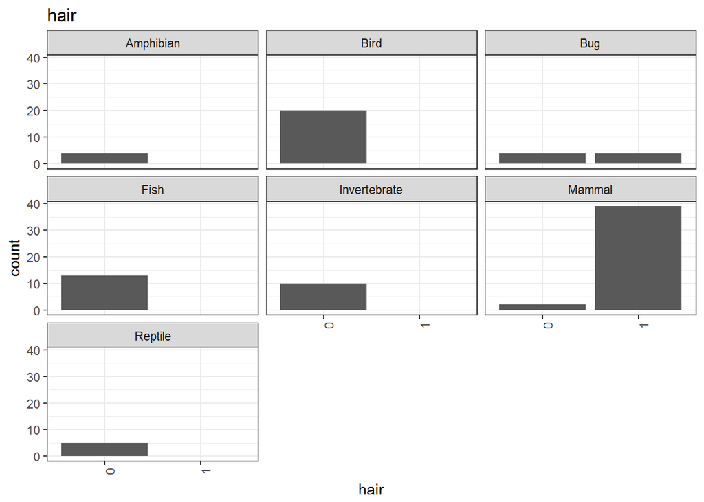

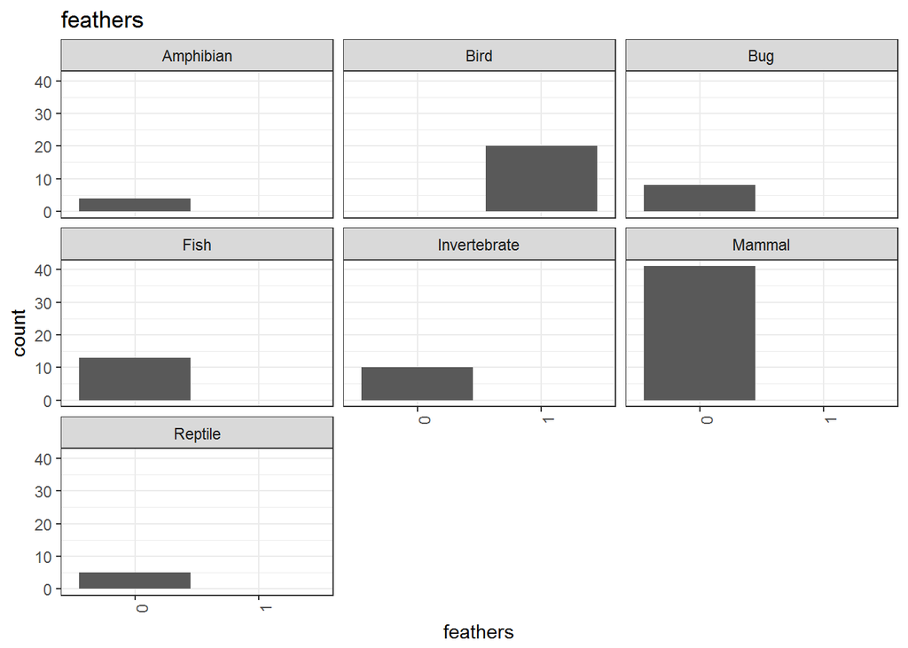

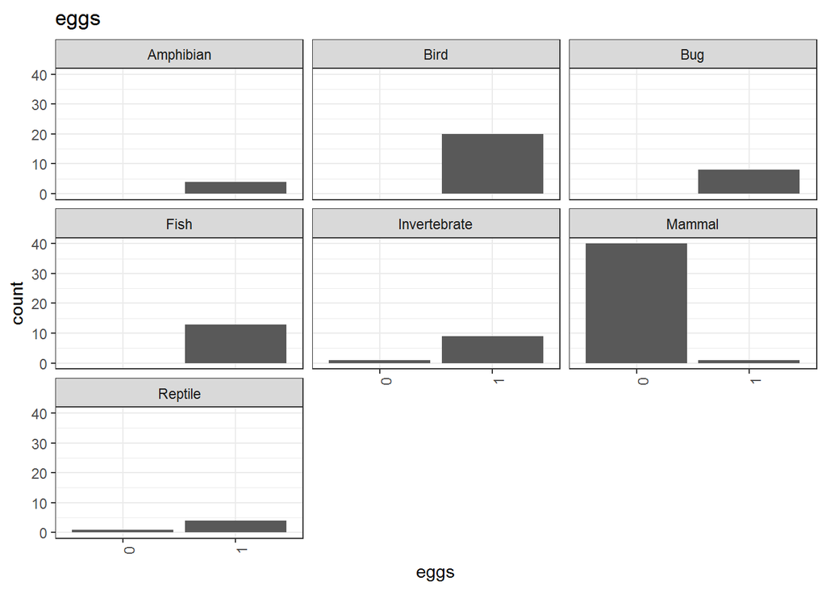

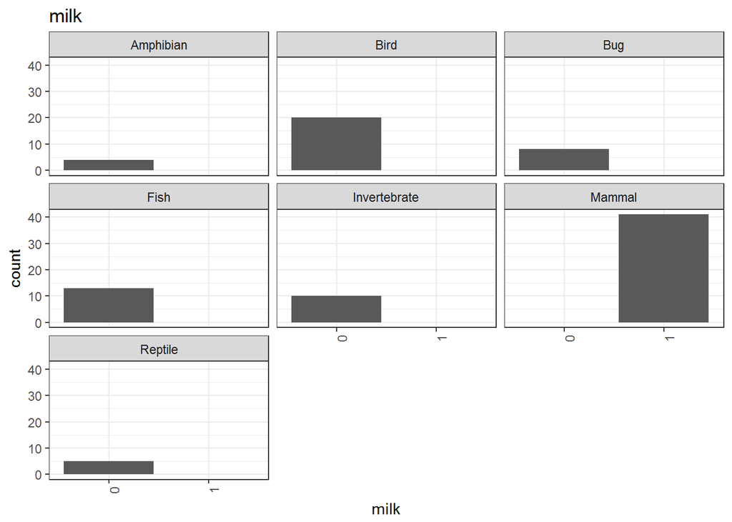

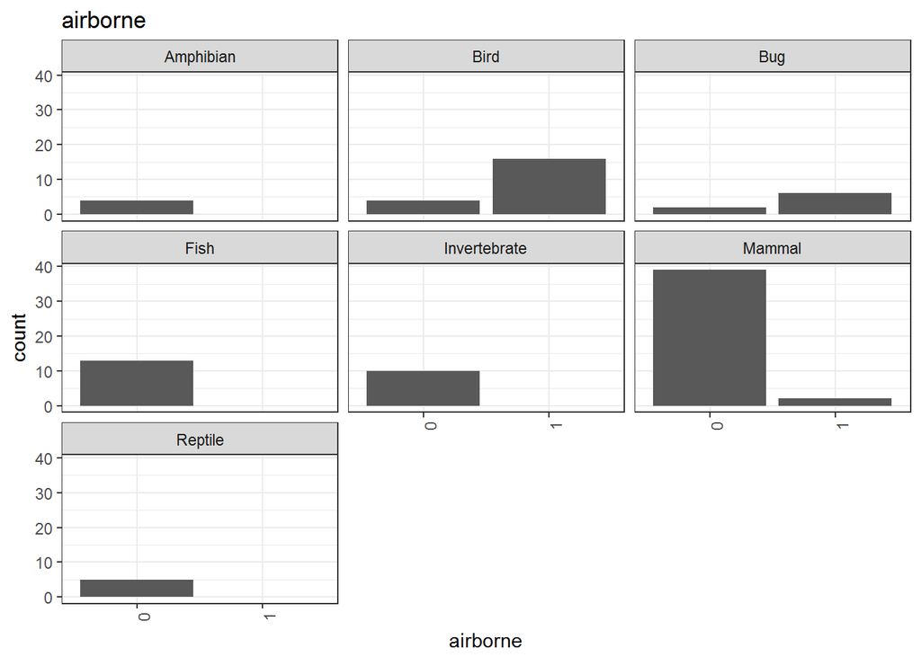

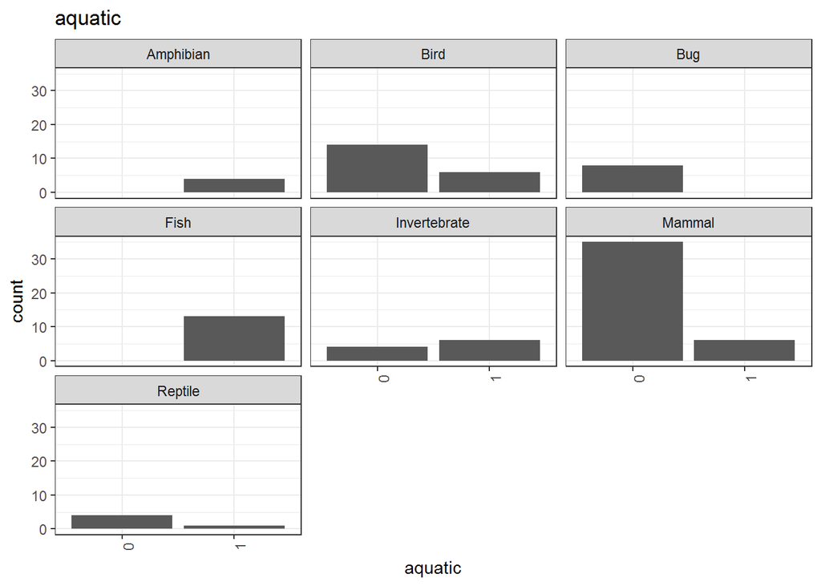

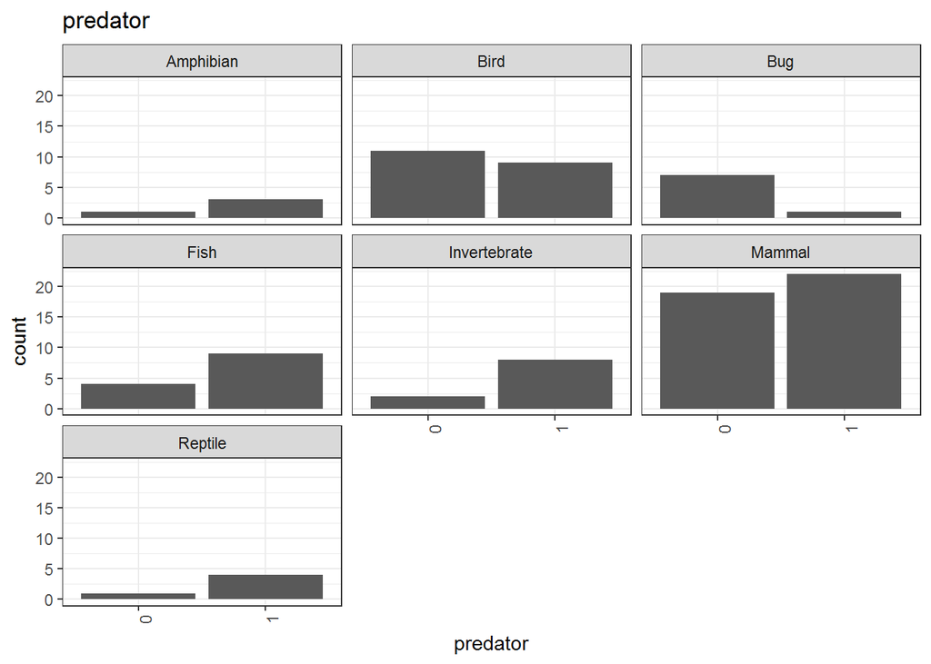

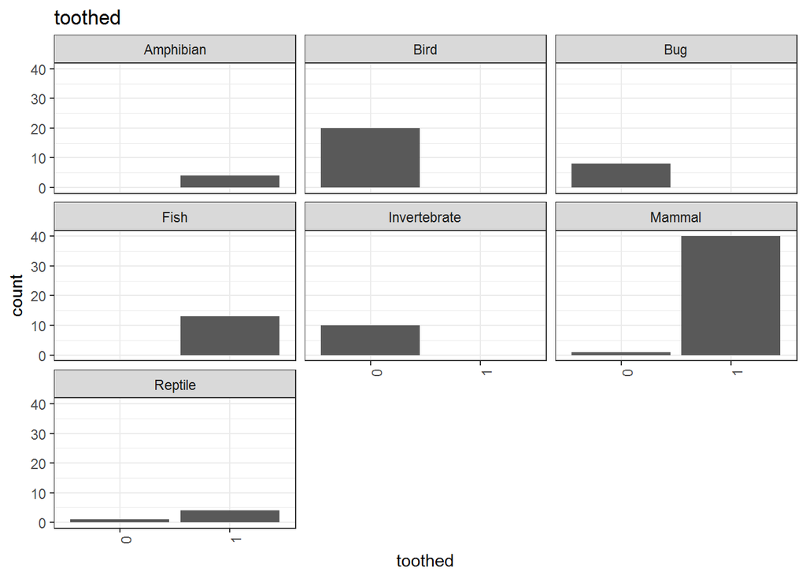

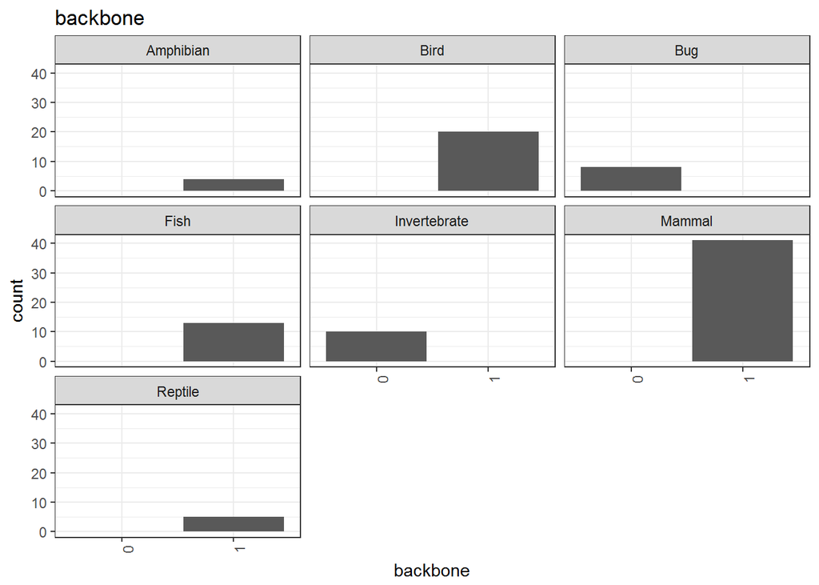

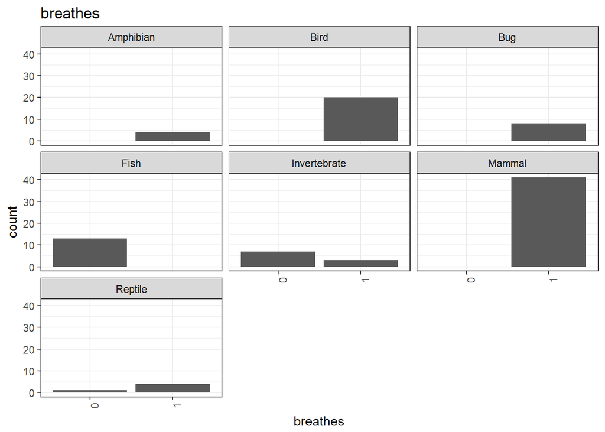

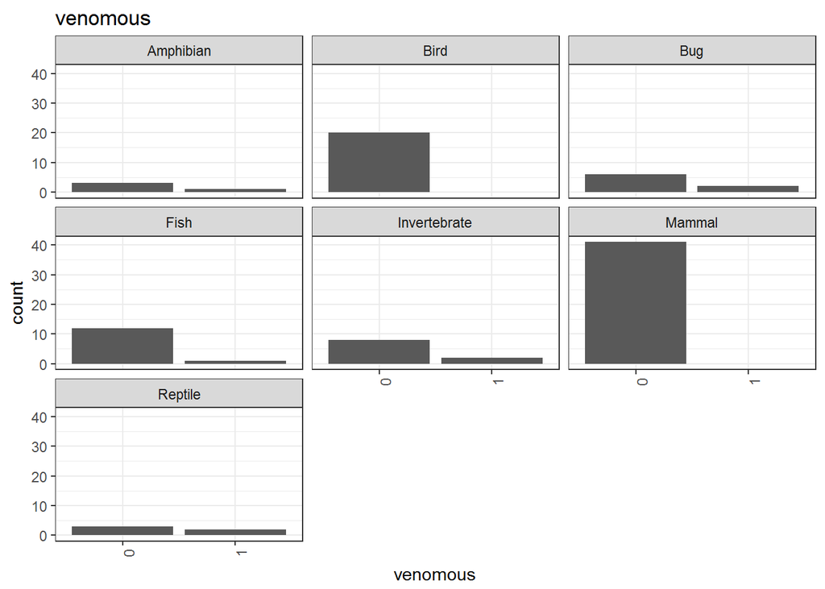

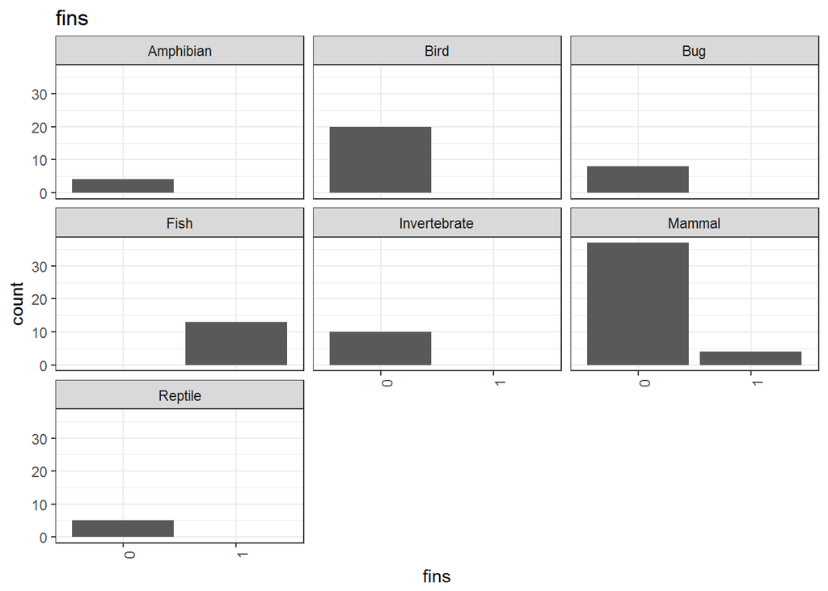

[4 more figures not shown]

### Supervised learning

Let’s try to build supervised machine learning model. In this one, I will use **SVM** from [e1071](https://cran.r-project.org/web/packages/e1071/e1071.pdf) library to build the model.

Setting up the training (70%) and testing (30%) datasets.

```r
intraining <- createDataPartition(y=zoo.data$class_type, p=0.7, list=F)
train.batch <- zoo.data[intraining,]
test.batch <- zoo.data[-intraining,]
```

Before going in the model part, due to the dataset size, I would like to do a quick check on each class sizing.

```
## ----- Training batch ------
```

```
##
##  1  2  3  4  5  6  7
## 29 14  4 10  3  6  7
```

```
## ----- Testing batch -----
```

```
##
##  1  2  3  4  5  6  7
## 12  6  1  3  1  2  3
```

Okay, this looks fine to me. Let’s dive to the model set up part.

```r
svm.model <- svm(class_type ~ .,
                 data=train.batch,
                 kernel = "radial")


summary(svm.model)
```

```
##
## Call:
## svm(formula = class_type ~ ., data = train.batch, kernel = "radial")
##
##
## Parameters:
##    SVM-Type:  C-classification
##  SVM-Kernel:  radial
##        cost:  1
##       gamma:  0.0625
##
## Number of Support Vectors:  45
##
##  ( 13 7 4 5 3 6 7 )
##
##
## Number of Classes:  7
##
## Levels:
##  1 2 3 4 5 6 7
```

```r
test.x <- select(test.batch,
            -class_type,
            -animal_name,
            -class_name)

test.y <- test.batch$class_type

test.pred <- predict(svm.model, test.x)
confusionMatrix(test.pred, test.y)
```

```
## Confusion Matrix and Statistics
##
##           Reference
## Prediction  1  2  3  4  5  6  7
##          1 12  0  0  0  0  0  0
##          2  0  6  1  0  0  0  0
##          3  0  0  0  0  1  0  0
##          4  0  0  0  3  0  0  0
##          5  0  0  0  0  0  0  0
##          6  0  0  0  0  0  2  0
##          7  0  0  0  0  0  0  3
##
## Overall Statistics
##
##                Accuracy : 0.9286
##                  95% CI : (0.765, 0.9912)
##     No Information Rate : 0.4286
##     P-Value [Acc > NIR] : 3.533e-08
##
##                   Kappa : 0.9026
##  Mcnemar's Test P-Value : NA
##
## Statistics by Class:
##
##                      Class: 1 Class: 2 Class: 3 Class: 4 Class: 5 Class: 6
## Sensitivity            1.0000   1.0000  0.00000   1.0000  0.00000  1.00000
## Specificity            1.0000   0.9545  0.96296   1.0000  1.00000  1.00000
## Pos Pred Value         1.0000   0.8571  0.00000   1.0000      NaN  1.00000
## Neg Pred Value         1.0000   1.0000  0.96296   1.0000  0.96429  1.00000
## Prevalence             0.4286   0.2143  0.03571   0.1071  0.03571  0.07143
## Detection Rate         0.4286   0.2143  0.00000   0.1071  0.00000  0.07143
## Detection Prevalence   0.4286   0.2500  0.03571   0.1071  0.00000  0.07143
## Balanced Accuracy      1.0000   0.9773  0.48148   1.0000  0.50000  1.00000
##                      Class: 7
## Sensitivity            1.0000
## Specificity            1.0000
## Pos Pred Value         1.0000
## Neg Pred Value         1.0000
## Prevalence             0.1071
## Detection Rate         0.1071
## Detection Prevalence   0.1071
## Balanced Accuracy      1.0000
```